# BSMM-quiz-1

SOLUTIONS

Author

LLO

Published

Invalid Date

# Instructions

## Overview

Quiz 1 will be released on Monday, October 2, and is designed to be completed in 30 minutes.

The exam will consist of two parts:

1. **Part 1 - Conceptual:** Simple questions designed to evaluate your familiarity with the written course notes.
2. **Part 2 - Applied:** Data analysis in RStudio (like a usual lab, but simpler).

Go to the [GitHub organization](https://github.com/bsmm-8740-fall-2023) for the course and find the **quiz-1-[your github username]** repo to complete the quiz. Add your answers by editing the `quiz-1.qmd` file in your repository.

🍀 Good luck! 🍀

## Academic Integrity

By taking this exam, you pledge to that:

- I will not lie, cheat, or steal in my academic endeavors;
- I will conduct myself honorably in all my endeavors; and
- I will act if the Standard is compromised.

## Rules & Notes

- This is an individual assignment. Everything in your repository is for your eyes only.
- You may not collaborate or communicate anything about this exam to **anyone** except the instructor. For example, you may not communicate with other students or post/solicit help on the internet, email or via any other method of communication.
- The exam is open-book, open-note, so you may use any materials from class as you take the exam.

## Submission

- Your answers should be typed in the document below
- Make sure you commit any changes to the document and push the changes to the course repository before he end of the quiz.
- Once the quiz has ended, the contents of your repository will be pulled for grading. This will happen only once, so no changes made after the end of the quiz will be recorded.

# Quiz-1 (part 1)

## Q-1

Is this data a `tidy` dataset?

| Region | < $1M | $1 - $5M | $5 - $10M | $10 - $100M | > $100M |
| --- | --- | --- | --- | --- | --- |
| N America | $50M | $324M | $1045M | $941M | $1200M |
| EMEA | $10M | $121M | $77M | $80M | $0M |

*Delete the wrong answer:*

**SOLUTION: the answer is No**

The category names appear as column names, while the values are spread out across the tables. The Tidy version would have just two columns - Region and income_band. The is could be achieved by transforming the table using `tidyr::pivot_longer()`

- Yes
- No

## Q-2

Which `dlpyr::` function possibly reduces the number of rows in a dataset? *Delete the wrong answers below*.

**SOLUTION: The answer is **`dplyr::filter`**

The function `dplyr::select()` selects columns, not rows, and the function `dplyr::arrange()`orders rows, but does not remove any. By contrast `dplyr::filter` will select only those rows meeting the filter criteria, and will thus return less than or equal to the number of current rows.

- **dplyr::select()**
- **dplyr::arrange()**
- **dplyr::filter**

## Q-3

If I join the *two* tables below as follows:

```r
dplyr::????_join(employees, departments, by = "department_id")
```

which type of join would include **employee_name == Moe Syzslak**?

**SOLUTION: the answer is `left_join`**

Inner join will return all the rows with common **department ID**, and since **Moe Syzslak** has a NA **department ID**, with no match in the **department ID table**,his name won’t appear in the result of the join.

Right join will return the **departments** table and all the rows of **employees** with **department ID** in common with the **departments** table, and since Moe Syzslak has a NA **department ID**, with no match in the **department ID table**,his name won’t appear in the result of the join.

See the code below.

- inner
- left
- right
- all of the above

*Delete the incorrect answers*.

**employees** - This table contains each employee’s ID, name, and department ID.

| id | employee_name | department_id |
| --- | --- | --- |
| 1 | Homer Simpson | 4 |
| 2 | Ned Flanders | 1 |
| 3 | Barney Gumble | 5 |
| 4 | Clancy Wiggum | 3 |
| 5 | Moe Syzslak | NA |

**departments** - This table contains each department’s ID and name.

| department_id | department_name |
| --- | --- |
| 1 | Sales |
| 2 | Engineering |
| 3 | Human Resources |
| 4 | Customer Service |
| 5 | Research And Development |

```r
tbl1 <- tibble::tribble(
~id , ~employee_name,   ~department_id
,1  ,'Homer Simpson'    ,4
,2  ,'Ned Flanders'   ,1
,3  ,'Barney Gumble'    ,5
,4  ,'Clancy Wiggum'    ,3
,5  ,'Moe Syzslak'    ,NA
)

tbl2 <- tibble::tribble(
~department_id  ,~department_name
,1  ,"Sales"
,2  ,"Engineering"
,3  ,"Human Resources"
,4  ,"Customer Service"
,5  ,"Research And Development"
)

print('left_join'); dplyr::left_join(tbl1,tbl2,by = "department_id")
print('right_join'); dplyr::right_join(tbl1,tbl2,by = "department_id")
print('inner_join'); dplyr::inner_join(tbl1,tbl2,by = "department_id")
```

```
[1] "left_join"
```

```
# A tibble: 5 × 4
     id employee_name department_id department_name
  <dbl> <chr>                 <dbl> <chr>
1     1 Homer Simpson             4 Customer Service
2     2 Ned Flanders              1 Sales
3     3 Barney Gumble             5 Research And Development
4     4 Clancy Wiggum             3 Human Resources
5     5 Moe Syzslak              NA <NA>
```

```
[1] "right_join"
```

```
# A tibble: 5 × 4
     id employee_name department_id department_name
  <dbl> <chr>                 <dbl> <chr>
1     1 Homer Simpson             4 Customer Service
2     2 Ned Flanders              1 Sales
3     3 Barney Gumble             5 Research And Development
4     4 Clancy Wiggum             3 Human Resources
5    NA <NA>                      2 Engineering
```

```
[1] "inner_join"
```

```
# A tibble: 4 × 4
     id employee_name department_id department_name
  <dbl> <chr>                 <dbl> <chr>
1     1 Homer Simpson             4 Customer Service
2     2 Ned Flanders              1 Sales
3     3 Barney Gumble             5 Research And Development
4     4 Clancy Wiggum             3 Human Resources
```

## Q-4

Give two questions you might ask of the data during exploratory data analysis.

**SOLUTION: there are many!**

You might ask:

- Is there missing data, and if so which columns/rows have missing data
- pick any two columns; can I see a relationship between them by plotting
- how are the numerical variables distributed
- how are the categorical variables encoded
- how many rows and columns are in the data set.
- …
1. ___
2. ___

## Q-5

If you thought your data had seasonality, what type of feature might you add to your predictive variables?

**SOLUTION: I’ll accept 1,2,3,or 4**

Lag variables can be used as a predictor that captures seasonality, if you pick the right lag. A sum of basis functions like `sin()` and `cos()` are often used to capture seasonality, Finally, date-part features are also frequently used to capture seasonality in the data, e.g. for seasonality of sale volumes, a month-of-year feature can be a good predictor.

1. lag variables
2. basis functions
3. date-part variables
4. all of the 1,2,3
5. none of 1,2,3

*Delete the incorrect answers*.

# Quiz-1 (part 2)

## Q6

Write code to determine the number of **species** of penguin in the dataset. How many are there?

**SOLUTION:**

```r
palmerpenguins::penguins %>%
  dplyr::distinct(species)
# == OR ==
palmerpenguins::penguins$species %>%
  unique() %>% length()
```

```
# A tibble: 3 × 1
  species
  <fct>
1 Adelie
2 Gentoo
3 Chinstrap
```

```
[1] 3
```

## Q7

Using one of the packages we discussed in class write code to perform EDA on the data

**SOLUTION:**

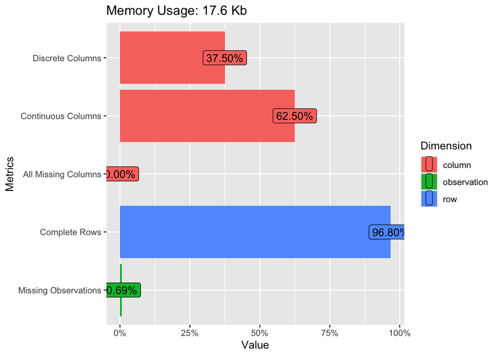

```r
palmerpenguins::penguins %>% DataExplorer::plot_intro()
```

```r
# == OR ==
palmerpenguins::penguins %>% skimr::skim()
```

Data summary

| Name | Piped data |
| --- | --- |
| Number of rows | 344 |
| Number of columns | 8 |
| _______________________ |  |
| Column type frequency: |  |
| factor | 3 |
| numeric | 5 |
| ________________________ |  |
| Group variables | None |

**Variable type: factor**

| skim_variable | n_missing | complete_rate | ordered | n_unique | top_counts |
| --- | --- | --- | --- | --- | --- |
| species | 0 | 1.00 | FALSE | 3 | Ade: 152, Gen: 124, Chi: 68 |
| island | 0 | 1.00 | FALSE | 3 | Bis: 168, Dre: 124, Tor: 52 |
| sex | 11 | 0.97 | FALSE | 2 | mal: 168, fem: 165 |

**Variable type: numeric**

| skim_variable | n_missing | complete_rate | mean | sd | p0 | p25 | p50 | p75 | p100 | hist |
| --- | --- | --- | --- | --- | --- | --- | --- | --- | --- | --- |
| bill_length_mm | 2 | 0.99 | 43.92 | 5.46 | 32.1 | 39.23 | 44.45 | 48.5 | 59.6 | ▃▇▇▆▁ |
| bill_depth_mm | 2 | 0.99 | 17.15 | 1.97 | 13.1 | 15.60 | 17.30 | 18.7 | 21.5 | ▅▅▇▇▂ |
| flipper_length_mm | 2 | 0.99 | 200.92 | 14.06 | 172.0 | 190.00 | 197.00 | 213.0 | 231.0 | ▂▇▃▅▂ |
| body_mass_g | 2 | 0.99 | 4201.75 | 801.95 | 2700.0 | 3550.00 | 4050.00 | 4750.0 | 6300.0 | ▃▇▆▃▂ |
| year | 0 | 1.00 | 2008.03 | 0.82 | 2007.0 | 2007.00 | 2008.00 | 2009.0 | 2009.0 | ▇▁▇▁▇ |

## Q8

Write code to add a column that counts the number of penguins in each `species-island` group.

**SOLUTION: 5 species-island groups**

```r
palmerpenguins::penguins %>%
  dplyr::group_by(species, island) %>%
  dplyr::mutate(count = dplyr::n(), .after = species) %>%
  dplyr::distinct(species, count)
```

```
# A tibble: 5 × 3
# Groups:   species, island [5]
  island    species   count
  <fct>     <fct>     <int>
1 Torgersen Adelie       52
2 Biscoe    Adelie       44
3 Dream     Adelie       56
4 Biscoe    Gentoo      124
5 Dream     Chinstrap    68
```

```r
# == OR ==
palmerpenguins::penguins %>%
  dplyr::count(species, island)  # not discussed in class
```

```
# A tibble: 5 × 3
  species   island        n
  <fct>     <fct>     <int>
1 Adelie    Biscoe       44
2 Adelie    Dream        56
3 Adelie    Torgersen    52
4 Chinstrap Dream        68
5 Gentoo    Biscoe      124
```

## Q9

Finish the code below to explore the distribution of flipper lengths among species. Which species has the longest flippers on average?

**SOLUTION: Gentoo has the longest flippers on average**

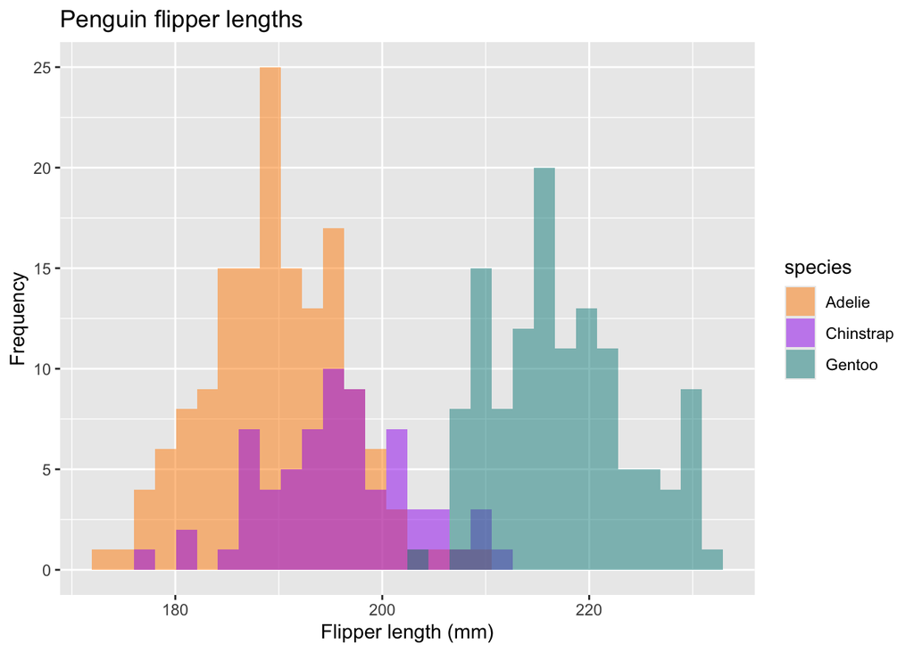

```r
flipper_hist <- ggplot(data = palmerpenguins::penguins, aes(x = flipper_length_mm)) +
  geom_histogram(aes(fill = species),
                 alpha = 0.5,
                 position = "identity") +
  scale_fill_manual(values = c("darkorange","purple","cyan4")) +
  labs(x = "Flipper length (mm)",
       y = "Frequency",
       title = "Penguin flipper lengths")

flipper_hist
```

## Q10

Write code to eliminate any rows that contain `NA` values. How many rows were left?

**SOLUTION: 344 - 333 = 11 rows removed**

```r
palmerpenguins::penguins %>%
  tidyr::drop_na()
```

```
# A tibble: 333 × 8
   species island    bill_length_mm bill_depth_mm flipper_length_mm body_mass_g
   <fct>   <fct>              <dbl>         <dbl>             <int>       <int>
 1 Adelie  Torgersen           39.1          18.7               181        3750
 2 Adelie  Torgersen           39.5          17.4               186        3800
 3 Adelie  Torgersen           40.3          18                 195        3250
 4 Adelie  Torgersen           36.7          19.3               193        3450
 5 Adelie  Torgersen           39.3          20.6               190        3650
 6 Adelie  Torgersen           38.9          17.8               181        3625
 7 Adelie  Torgersen           39.2          19.6               195        4675
 8 Adelie  Torgersen           41.1          17.6               182        3200
 9 Adelie  Torgersen           38.6          21.2               191        3800
10 Adelie  Torgersen           34.6          21.1               198        4400
# ℹ 323 more rows
# ℹ 2 more variables: sex <fct>, year <int>
```

# Grading (10 pts)

| **Part** | **Points** |
| --- | --- |
| **Part 1 - Conceptual** | 5 |
| **Part 2 - Applied** | 5 |
| **Total** | 10 |